# The War with Star Wars

- Show All Code
- Hide All Code

Using a Decision Tree to Predict Whether a Person Makes Over $50K

Author

Erin_Hu

### Elevator pitch

```python
# %%
url = 'https://github.com/fivethirtyeight/data/raw/master/star-wars-survey/StarWars.csv'

df_cols = pd.read_csv(url, encoding = "ISO-8859-1", nrows = 1).melt()
df = pd.read_csv(url, encoding = "ISO-8859-1", skiprows =2, header = None )
```

### Shorten and Clean Data |Question 1

**Shorten the column names and clean them up for easier use with pandas. Provide a table or list that exemplifies how you fixed the names.**

```python
variables_replace = {
    'Which of the following Star Wars films have you seen\\? Please select all that apply\\.':'Seen',
    'Please rank the Star Wars films in order of preference with 1 being your favorite film in the franchise and 6 being your least favorite film.':'Rank',
    'Please state whether you view the following characters favorably, unfavorably, or are unfamiliar with him/her.':'view',
    'Do you consider yourself to be a fan of the Star Trek franchise\\?':'is_fan_star_trek',
    'Do you consider yourself to be a fan of the Expanded Universe\\?\x8cæ':'is_fan_universe',
    'Are you familiar with the Expanded Universe\\?':'know_universe',
    'Have you seen any of the 6 films in the Star Wars franchise\\?':'seen_any',
    'Do you consider yourself to be a fan of the Star Wars film franchise\\?':'star_wars_fans',
    'Which character shot first\\?':'shot_first',
    'Unnamed: \d{1,2}':np.nan,
    ' ':'_',
}

values_replace = {
    'Response':'',
    'Star Wars: Episode ':'',
    ' ':'_'
}


df_cols_use = (df_cols
    .assign(
        value_replace = lambda x:  x.value.str.strip().replace(values_replace, regex=True),
        variable_replace = lambda x: x.variable.str.strip().replace(variables_replace, regex=True)
    )
    .fillna(method = 'ffill')
    .fillna(value = "")
    .assign(column_names = lambda x: x.variable_replace.str.cat(x.value_replace, sep = "__").str.strip('__').str.lower())
    )

df.columns = df_cols_use.column_names.to_list()
df_cols_use.head(5)
```

|  | variable | value | value_replace | variable_replace | column_names |
| --- | --- | --- | --- | --- | --- |
| 0 | RespondentID |  |  | RespondentID | respondentid |
| 1 | Have you seen any of the 6 films in the Star W... | Response |  | seen_any | seen_any |
| 2 | Do you consider yourself to be a fan of the St... | Response |  | star_wars_fans | star_wars_fans |
| 3 | Which of the following Star Wars films have yo... | Star Wars: Episode I The Phantom Menace | I__The_Phantom_Menace | Seen | seen__i__the_phantom_menace |
| 4 | Unnamed: 4 | Star Wars: Episode II Attack of the Clones | II__Attack_of_the_Clones | Seen | seen__ii__attack_of_the_clones |

we have combined the data’s two column titles into more precies columns and made it easier for our computer to read, as we are preping to use it in graphs and a ML model.

### Clean and Format |Question 2

**Clean and format the data so that it can be used in a machine learning model. As you format the data, you should complete each item listed below. In your final report provide example(s) of the reformatted data with a short description of the changes made.**

### |Part A

**Filter the dataset to respondents that have seen at least one film**

```python
seen_columns = [
    'seen__i__the_phantom_menace',
    'seen__ii__attack_of_the_clones',
    'seen__iii__revenge_of_the_sith',
    'seen__iv__a_new_hope',
    'seen__v_the_empire_strikes_back',
    'seen__vi_return_of_the_jedi'
]
# Filter out respondents who have seen any Star Wars movie but haven't specified any
have_seen_df = df[df[seen_columns].notna().any(axis=1)]
```

looking at if respondents put down the name of a Star Wars movie, and then filtered to people who put down at least on title. this is the data frame that we will be filtering.

### |Part B

**Create a new column that converts the age ranges to a single number. Drop the age range categorical column**

```python
# Convert age ranges to a single number and drop the original column
have_seen_df['age_num'] = (have_seen_df['age']
        .str.replace(">", "")
        .str.replace('18-29', '1')
        .str.replace('30-44', '2')
        .str.replace('45-60', '3')
        .str.replace('60', '4')
        .astype('float'))
have_seen_df = have_seen_df.drop(columns=['age'])
```

filiting the age column from a string, into a number so it is computable.

### |Part C

**Create a new column that converts the education groupings to a single number. Drop the school categorical column**

```python
#clean up and convert education
have_seen_df['education_num'] = (have_seen_df['education']
        .replace(np.nan, '0')
        .str.replace('Less than high school degree', '8')
        .str.replace('High school degree', '12')
        .str.replace('Some college or Associate degree', '14')
        .str.replace('Bachelor degree', '16')
        .str.replace('Graduate degree', '20')
        .astype('float'))
have_seen_df = have_seen_df.drop(columns=['education'])
```

### |Part D

**Create a new column that converts the income ranges to a single number. Drop the income range categorical column**

```python
# %%
#clean up and remove symbols
new_income = (have_seen_df['household_income']
        .str.split("-", expand=True)
        .rename(columns={0: 'income_min', 1: 'income_max'})
        .apply(lambda x: x.str.replace("$", ""))
        .apply(lambda x: x.str.replace(",", ""))
        .apply(lambda x: x.str.replace("+", ""))
        .astype('float'))

# Join the new income columns back to the DataFrame
have_seen_df = pd.concat([have_seen_df, new_income['income_min']], axis=1)
have_seen_df = have_seen_df.drop(columns=['household_income'])
```

making income into one column by puting the minimum range number as the only number present in the column.

### |Part E

**Create your target (also known as “y” or “label”) column based on the new income range column**

```python
have_seen_df['income_target'] = have_seen_df['income_min'].apply(lambda x: 1 if x < 50000 else 0)
```

```python
# Assuming df is already defined
pd.set_option('future.no_silent_downcasting', True)

columns_to_transform = ['view__han_solo', 'view__luke_skywalker', 'view__princess_leia_organa', 'view__anakin_skywalker', 'view__obi_wan_kenobi', 'view__emperor_palpatine', 'view__darth_vader', 'view__lando_calrissian', 'view__boba_fett', 'view__c-3p0', 'view__r2_d2', 'view__jar_jar_binks', 'view__padme_amidala', 'view__yoda']

for col in columns_to_transform:
    have_seen_df[col] = (have_seen_df[col]
               .replace('Very favorably', 2)
               .replace('Somewhat favorably', 1)
               .replace([np.nan, 'Unfamiliar (N/A)', 'Neither favorably nor unfavorably (neutral)'], 0)
               .replace('Somewhat unfavorably', -1)
               .replace('Very unfavorably', -2)
               .astype(int))
```

### |Part F

**One-hot encode all remaining categorical columns**

```python
# %%
# One-hot encoding
categorical_columns = ['seen__i__the_phantom_menace', 'seen__ii__attack_of_the_clones', 'seen__iii__revenge_of_the_sith', 'seen__iv__a_new_hope', 'seen__v_the_empire_strikes_back', 'seen__vi_return_of_the_jedi']

have_seen_df[categorical_columns] = have_seen_df[categorical_columns].notna().astype(int)

# Perform one-hot encoding on 'location_(census_region)' and 'shot_first'
one_hot_df = pd.get_dummies(have_seen_df[['location_(census_region)', 'shot_first']], drop_first=True)

# Concatenate one-hot encoded columns with the original DataFrame
have_seen_df = pd.concat([have_seen_df, one_hot_df], axis=1)

# Drop the original categorical columns used for one-hot encoding
have_seen_df = have_seen_df.drop(columns=['location_(census_region)', 'shot_first'])
```

Hot code the shot_first data, and location data to turn it into nubmers and computable. as well as turnign the seen columns into 1’s if a title and no answers into 0’s.

```python
# Combine all transformed columns into the final DataFrame
final_df = have_seen_df.copy()

# Ensure binary representation for all boolean columns
final_df = final_df.replace([True, 'Yes', 'Male'], 1).replace([False, 'No', np.nan, 'Female'], 0)
final_df
```

|  | respondentid | seen_any | star_wars_fans | seen__i__the_phantom_menace | seen__ii__attack_of_the_clones | seen__iii__revenge_of_the_sith | seen__iv__a_new_hope | seen__v_the_empire_strikes_back | seen__vi_return_of_the_jedi | rank__i__the_phantom_menace | ... | location_(census_region)_East South Central | location_(census_region)_Middle Atlantic | location_(census_region)_Mountain | location_(census_region)_New England | location_(census_region)_Pacific | location_(census_region)_South Atlantic | location_(census_region)_West North Central | location_(census_region)_West South Central | shot_first_Han | shot_first_I don't understand this question |
| --- | --- | --- | --- | --- | --- | --- | --- | --- | --- | --- | --- | --- | --- | --- | --- | --- | --- | --- | --- | --- | --- |
| 0 | 3292879998 | 1 | 1 | 1 | 1 | 1 | 1 | 1 | 1 | 3.0 | ... | 0 | 0 | 0 | 0 | 0 | 1 | 0 | 0 | 0 | 1 |
| 2 | 3292765271 | 1 | 0 | 1 | 1 | 1 | 0 | 0 | 0 | 1.0 | ... | 0 | 0 | 0 | 0 | 0 | 0 | 1 | 0 | 0 | 1 |
| 3 | 3292763116 | 1 | 1 | 1 | 1 | 1 | 1 | 1 | 1 | 5.0 | ... | 0 | 0 | 0 | 0 | 0 | 0 | 1 | 0 | 0 | 1 |
| 4 | 3292731220 | 1 | 1 | 1 | 1 | 1 | 1 | 1 | 1 | 5.0 | ... | 0 | 0 | 0 | 0 | 0 | 0 | 1 | 0 | 0 | 0 |
| 5 | 3292719380 | 1 | 1 | 1 | 1 | 1 | 1 | 1 | 1 | 1.0 | ... | 0 | 1 | 0 | 0 | 0 | 0 | 0 | 0 | 1 | 0 |
| ... | ... | ... | ... | ... | ... | ... | ... | ... | ... | ... | ... | ... | ... | ... | ... | ... | ... | ... | ... | ... | ... |
| 1180 | 3288389603 | 1 | 1 | 1 | 1 | 1 | 1 | 1 | 1 | 3.0 | ... | 0 | 0 | 0 | 0 | 1 | 0 | 0 | 0 | 1 | 0 |
| 1181 | 3288388730 | 1 | 1 | 1 | 1 | 1 | 1 | 1 | 1 | 5.0 | ... | 0 | 0 | 0 | 0 | 0 | 0 | 0 | 0 | 1 | 0 |
| 1182 | 3288378779 | 1 | 1 | 1 | 1 | 1 | 1 | 1 | 1 | 4.0 | ... | 0 | 0 | 1 | 0 | 0 | 0 | 0 | 0 | 0 | 1 |
| 1184 | 3288373068 | 1 | 1 | 1 | 1 | 1 | 1 | 1 | 1 | 4.0 | ... | 0 | 0 | 0 | 0 | 0 | 0 | 0 | 0 | 1 | 0 |
| 1185 | 3288372923 | 1 | 0 | 1 | 1 | 0 | 0 | 1 | 1 | 6.0 | ... | 0 | 0 | 0 | 0 | 1 | 0 | 0 | 0 | 0 | 1 |

835 rows × 47 columns

This is the final filtered data frame. This has 835 respondents and we are using this to make graphs and the ML model.

### Validate |Question 3

**Validate that the data provided on GitHub lines up with the article by recreating 2 of the visuals from the article.**

```python
# Calculate percentages
han_count = final_df['shot_first_Han'].sum()
greedo_count = ((final_df['shot_first_Han'] == 0) & (final_df["shot_first_I don't understand this question"] == 0)).sum()
dont_understand_count = final_df["shot_first_I don't understand this question"].sum()

total_responses = len(final_df)

han_percent = (han_count / total_responses) * 100
greedo_percent = (greedo_count / total_responses) * 100
dont_understand_percent = (dont_understand_count / total_responses) * 100
greedo_percent_rounded = math.floor(greedo_percent)


# Create a DataFrame with the percentages
shot_data = pd.DataFrame({
    'Who_Shot_First': ["I don't understand this question", 'Greedo', 'Han'],
    'Percent': [dont_understand_percent, greedo_percent_rounded, han_percent]
})

# Create the bar chart using Plotly
shot_chart = px.bar(
    shot_data,
    x='Percent',
    y='Who_Shot_First',
    orientation='h',  # horizontal bars
    title="Who Shot First?",  # Title of the chart
)

# Update layout with annotations and subtitle

# Update layout with annotations and subtitle
shot_chart.update_layout(
    annotations=[
        {
            'x': percent,
            'y': category,
            'text': f'{percent:.0f}%',  # Display percentage with two decimal places
            'showarrow': False,
            'font': {'color': 'black', 'size': 12},
            'xanchor': 'left' if percent < 50 else 'right'  # Align text based on bar position
        }
        for percent, category in zip(shot_data['Percent'], shot_data['Who_Shot_First'])
    ],
)
# Add subtitle directly using add_annotation()
shot_chart.add_annotation(
    text='According to 834 respondents',  # Subtitle text
    x=-0,  # Subtitle position (middle of the chart)
    y=1.15,  # Subtitle position (above the chart)
    xref='paper',  # Subtitle alignment (relative to the entire chart width)
    yref='paper',  # Subtitle alignment (relative to the entire chart height)
    showarrow=False,  # No arrow for the annotation
    font=dict(size=12, color='black'),  # Font settings for the subtitle text
)

# Show the chart
shot_chart.show()
```

[interactive chart not shown]

This is the replica of the How Shot First graph from the artical.

```python
# Calculate percentages
Phantom = final_df['seen__i__the_phantom_menace'].sum()
clones = final_df['seen__ii__attack_of_the_clones'].sum()
Revenge = final_df['seen__iii__revenge_of_the_sith'].sum()
Hope = final_df['seen__iv__a_new_hope'].sum()
Empire = final_df['seen__v_the_empire_strikes_back'].sum()
Return = final_df['seen__vi_return_of_the_jedi'].sum()

total_responses = len(final_df)

Phantom_percent = (Phantom / total_responses) * 100
clones_percent = (clones / total_responses) * 100
Revenge_percent = (Revenge / total_responses) * 100
Hope_percent = (Hope / total_responses) * 100
Empire_percent  = (Empire  / total_responses) * 100
Return_percent = (Return / total_responses) * 100

Phantom_percent = math.floor(Phantom_percent)


# Create a DataFrame with the percentages
shot_data = pd.DataFrame({
    'movies': ["Return of the Jedi", ' The empire Strikes Back', ' A New Hope', 'Revenge fo the Sith', 'Attack of the Clones', 'The Phantom Menace'],
    'Percent': [Return_percent, Empire_percent, Hope_percent,Revenge_percent, clones_percent, Phantom_percent]
})

# Create the bar chart using Plotly
shot_chart = px.bar(
    shot_data,
    x='Percent',
    y='movies',
    orientation='h',  # horizontal bars
    title="Which 'Star Wars' Movies Have You Seen?",  # Title of the chart
)
shot_chart.update_layout(
    annotations=[
        {
            'x': percent,
            'y': category,
            'text': f'{percent:.0f}%',  # Display percentage with two decimal places
            'showarrow': False,
            'font': {'color': 'black', 'size': 12},
            'xanchor': 'left' if percent > 50 else 'right'  # Align text based on bar position
        }
        for percent, category in zip(shot_data['Percent'], shot_data['movies'])
    ],
)
# Add subtitle directly using add_annotation()
shot_chart.add_annotation(
    text='According to 834 respondents',  # Subtitle text
    x=-0,  # Subtitle position (middle of the chart)
    y=1.15,  # Subtitle position (above the chart)
    xref='paper',  # Subtitle alignment (relative to the entire chart width)
    yref='paper',  # Subtitle alignment (relative to the entire chart height)
    showarrow=False,  # No arrow for the annotation
    font=dict(size=12, color='black'),  # Font settings for the subtitle text
)

shot_chart
```

[interactive chart not shown]

This is the replica of which movie the respondents have seen from the artical.

### Machine Learning Model|Question 4

**Build a machine learning model that predicts whether a person makes more than $50k. Describe your model and report the accuracy.**

```python
columns_to_keep = ['age_num', 'gender', 'education_num', 'star_wars_fans', 'seen__iv__a_new_hope', 'seen__vi_return_of_the_jedi', 'seen__v_the_empire_strikes_back', 'location_(census_region)_West North Central','shot_first_Han','location_(census_region)_Middle Atlantic']

X_pred = final_df[columns_to_keep]
y_pred = final_df['income_target']
X_train, X_test, y_train, y_test = train_test_split(
    X_pred, y_pred, test_size = .30, random_state = 100)


clf = tree.DecisionTreeClassifier()
clf = clf.fit(X_train, y_train)
y_pred = clf.predict(X_test)
```

```python
df_features = pd.DataFrame(
    {'f_names': X_train.columns,
    'f_values': clf.feature_importances_}).sort_values('f_values', ascending = False)

chart = px.bar(df_features.head(15),
    x='f_values',
    y='f_names'
)

chart.update_layout(yaxis={'categoryorder':'total ascending'})
```

[interactive chart not shown]

```python
print(metrics.classification_report(y_pred, y_test))
```

```
              precision    recall  f1-score   support

           0       0.83      0.75      0.79       207
           1       0.20      0.30      0.24        44

    accuracy                           0.67       251
   macro avg       0.52      0.52      0.51       251
weighted avg       0.72      0.67      0.69       251
```

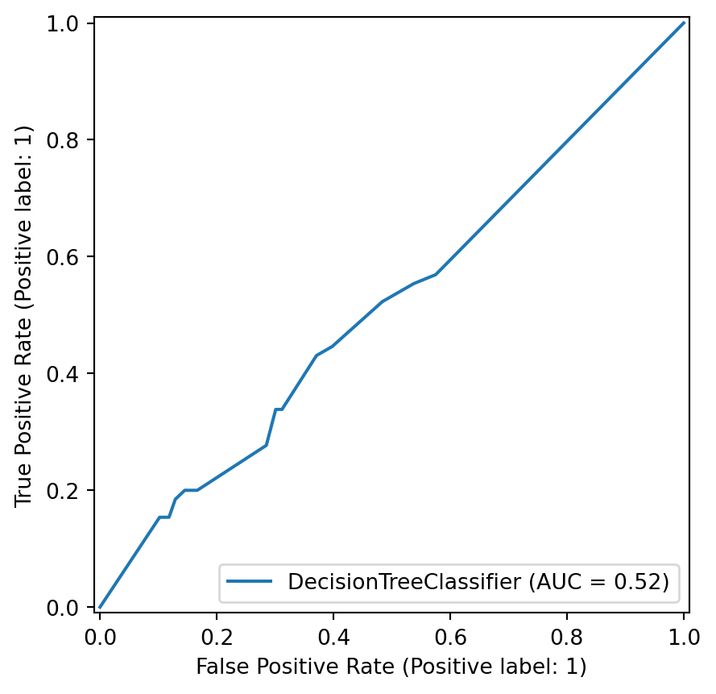

```python
metrics.RocCurveDisplay.from_estimator(clf, X_test, y_test)
```

```python
df_features = pd.DataFrame(
    {'f_names': X_train.columns,
    'f_values': clf.feature_importances_}).sort_values('f_values', ascending = False)
```

```python
df_features
```

|  | f_names | f_values |
| --- | --- | --- |
| 2 | education_num | 0.191504 |
| 0 | age_num | 0.134521 |
| 8 | shot_first_Han | 0.126145 |
| 1 | gender | 0.121391 |
| 7 | location_(census_region)_West North Central | 0.082345 |
| 3 | star_wars_fans | 0.078390 |
| 5 | seen__vi_return_of_the_jedi | 0.071597 |
| 9 | location_(census_region)_Middle Atlantic | 0.069335 |
| 4 | seen__iv__a_new_hope | 0.066287 |
| 6 | seen__v_the_empire_strikes_back | 0.058485 |

```python
confusion = metrics.confusion_matrix(y_test, y_pred)
confusion
```

```
array([[155,  31],
       [ 52,  13]])
```

```python
tp = confusion[0,0]
fp = confusion[1,0]
fn = confusion[0,1]
tn = confusion[1,1]
```

```python
precision = (tp / (tp+fp))
accuracy = ((tp+tn) / (tp+fn+fp+tn))
negative_prediction = (tn / (tn+fn))
metrics = {
    'Metric': ['Precision', 'Accuracy', 'Negative Prediction'],
    'Value': [precision, accuracy, negative_prediction]}

df = pd.DataFrame(metrics)
df
```

|  | Metric | Value |
| --- | --- | --- |
| 0 | Precision | 0.748792 |
| 1 | Accuracy | 0.669323 |
| 2 | Negative Prediction | 0.295455 |

This table shows our precision accuracy and negative rediction and how acurite they are out of 1. precision is a 75%, accuracy is 67% and our neagtive rediction is 30% acurrate.

Back to top